# Final Project Draft

Anwesha Guha

2/21/2021

## About the Data

Data was taken from the publicly available *fivethirtyeightdata* housed on GitHub. Specifically, I used the grad-students and recent-grads data, which are used in the “Economic Guide to Picking a College Major” [article](https://fivethirtyeight.com/features/the-economic-guide-to-picking-a-college-major/). The data is originally from the 2010-2012 American Community Survey and generally discusses earnings, graduate student information, and labor force outcomes.

## Plot 1

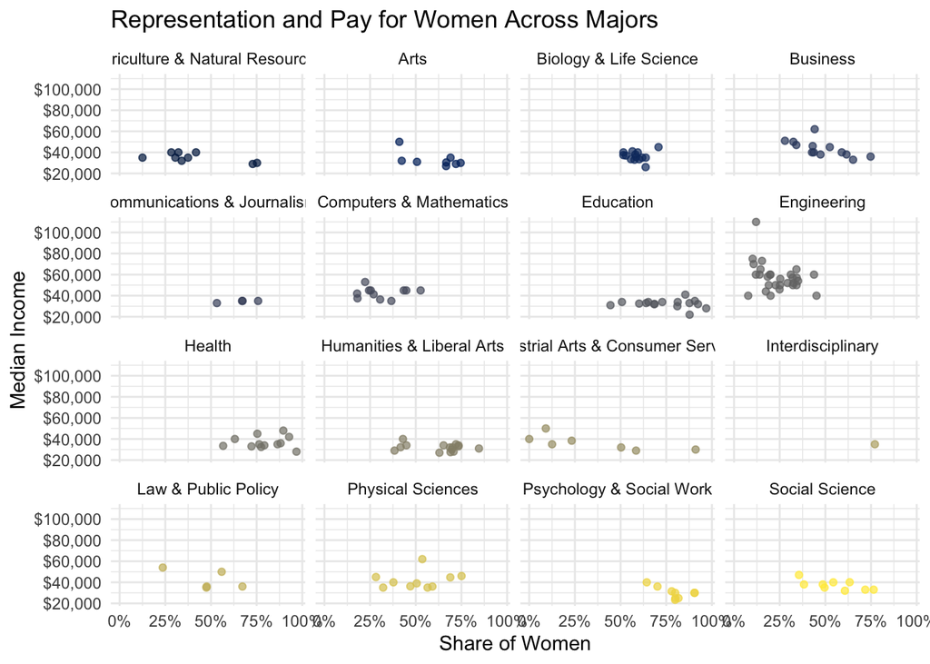

```r
recent_grad %>%
  ggplot(aes(sharewomen, median)) +
  geom_point(aes(color = major_category), alpha = 0.7) +
  facet_wrap(~major_category) +
  theme_minimal() +
  scale_color_viridis_d(option = "E") +
  theme(legend.position = "none") +
  scale_x_continuous(labels = scales::percent) +
  scale_y_continuous(labels = scales::dollar) +
  labs(x = "Share of Women",
       y = "Median Income",
       title = "Representation and Pay for Women Across Majors")
```

```r
# maybe include vertical line for average share of women, horizontal line for average income
```

### Comment: The visualization is pretty straightforward to understand. One thing I would like to suggest is that add some text to explain why majors are colored differently because people will not know how those are color if they can’t see you code. Also, it looks some labels on the x-axis are smashed together, and the title of individual plot is out of the view, but I don’t know how to fix them. I also like your ideas about adding vertical and horizontal lines.

## Plot 2

```r
recent_grad$employ_total <- recent_grad$employed_fulltime + recent_grad$employed_parttime + recent_grad$unemployed

recent_grad_prop <- recent_grad %>%
  group_by(major_category) %>%
  summarize(fulltime = sum(employed_fulltime)/sum(employ_total),
         parttime = sum(employed_parttime)/sum(employ_total),
         unemploy = sum(unemployed)/sum(employ_total)) %>%
  select(major_category, fulltime, parttime, unemploy) %>%
  pivot_longer(-major_category,
               names_to = "employment_type",
               values_to = "proportion")
```

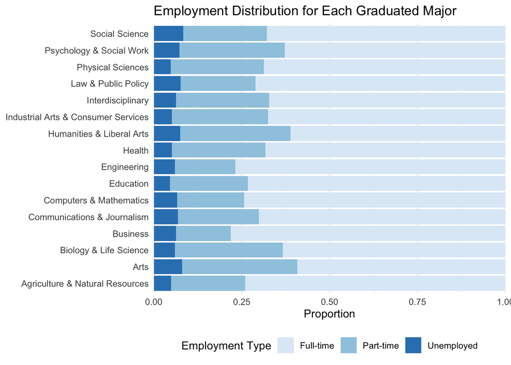

```r
recent_grad_prop %>%
  ggplot(aes(major_category, proportion)) +
  geom_col(aes(fill = employment_type)) +
#  geom_text(aes(label=scales::percent(proportion, 1)), size = 2, hjust = 2, color = "gray30") +
  coord_flip() +
  theme_minimal() +
  scale_fill_brewer(name = "Employment Type", labels = c("Full-time", "Part-time", "Unemployed")) +
  labs(y = "Proportion",
       x = NULL,
       title = "Employment Distribution for Each Graduated Major") +
  theme(legend.position = "bottom") +
  scale_y_continuous(expand = c(0,0))
```

```r
# Feedback on whether geom_text() adds anything here? I felt it looked a bit too cluttered
```

### Comment: I really like this visualization. It is clear to see what you try to compare and the color combination is pleasing. The only nitpicking thing I would say is that may use text to label the percentage (the line you commented out) for each major and employment type within a major. If you feel it is too cluttered, I think at least adding label the percentage for the full-time employment for each major would be helpful, or place the labels at the end of each employment type for each major.

## Plot 3

```r
recent_grad_sex <- recent_grad %>%
  group_by(major_category) %>%
  summarize(share_men = sum(men)/sum(total),
            share_women = sum(women)/sum(total),
            salary = mean(median)) %>%
  select(major_category, share_men, share_women, salary) %>%
  pivot_longer(-c(major_category, salary),
               names_to = "sex",
               values_to = "share")
```

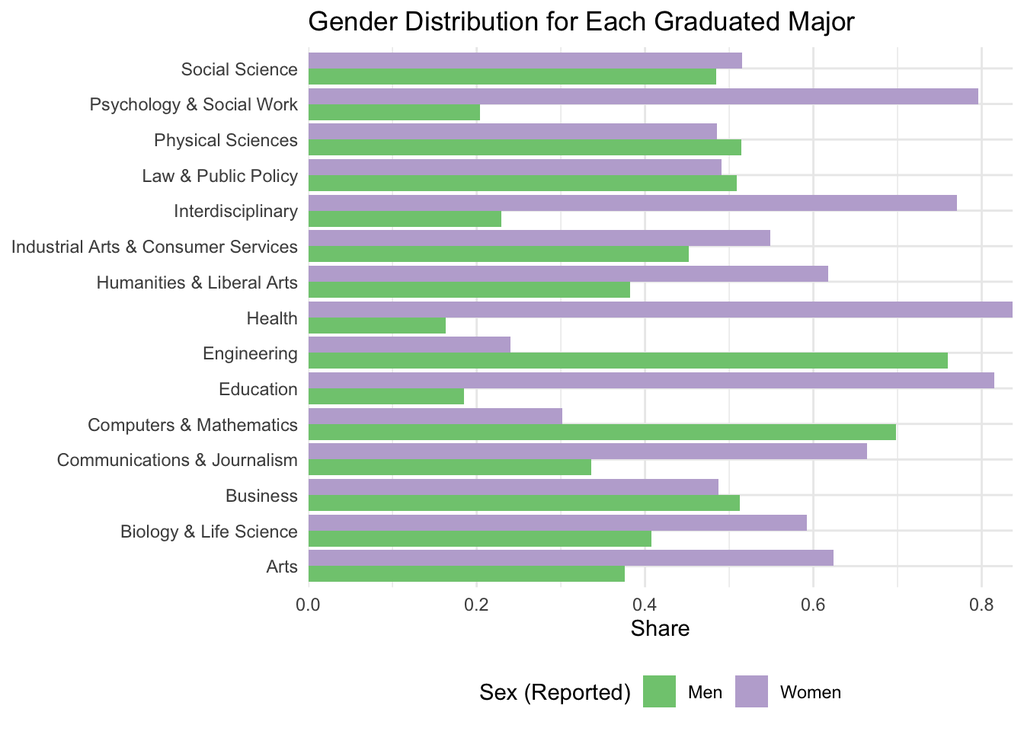

```r
recent_grad_sex %>%
  filter(major_category != "Agriculture & Natural Resources") %>%
  ggplot(aes(reorder(major_category, -share), share)) +
  geom_col(aes(fill = sex), position = "dodge") +
#  geom_text(aes(label=scales::percent(share, 1)), size = 2, hjust = 2, position = position_dodge(0.9)) +
  coord_flip() +
  theme_minimal() +
  scale_fill_brewer(name = "Sex (Reported)", labels = c("Men", "Women"), palette = "Accent") +
  labs(y = "Share",
       x = NULL,
       title = "Gender Distribution for Each Graduated Major") +
  theme(legend.position = "bottom") +
  scale_y_continuous(expand = c(0,0))
```

```r
# I would be interested to also include the median salary for each field, but am stuck on how to make that work well visually. Also can't get geom_text() to work here; feedback would be great!
```

### Comment: I think if you want to include the median salary (by gender? if I am understanding this correctly) for each field, maybe it is better to create two different plot objects in r and combine them with ggarrange to create one plot. Depending on what visualization you do with salary, I think it is better to make them look comparable. Howevever I currently don’t know how to make plots for gender distribution and salary look comparable.

## Plot 4

*This is an additional exploration with a different dataset. For my peer reviewer, you can ignore the plot below!*

```r
library(albersusa)

us <- usa_sf() %>%
  rename(state = iso_3166_2)

hate_crime_prop <- hate_crimes %>%
  rename(post_election = hate_crimes_per_100k_splc,
         pre_election = avg_hatecrimes_per_100k_fbi/6,
         state_full = state,
         state = state_abbrev) %>%
  select(state, post_election, pre_election) %>%
  pivot_longer(-state,
               names_to = "time_period",
               values_to = "crime_rate")

hate_crime_pre <- hate_crime_prop %>%
  filter(time_period == "pre_election")

hate_crime_post <- hate_crime_prop %>%
  filter(time_period == "post_election")

crime_map_before <- left_join(us, hate_crime_pre)
crime_map_after <- left_join(us, hate_crime_post)
```

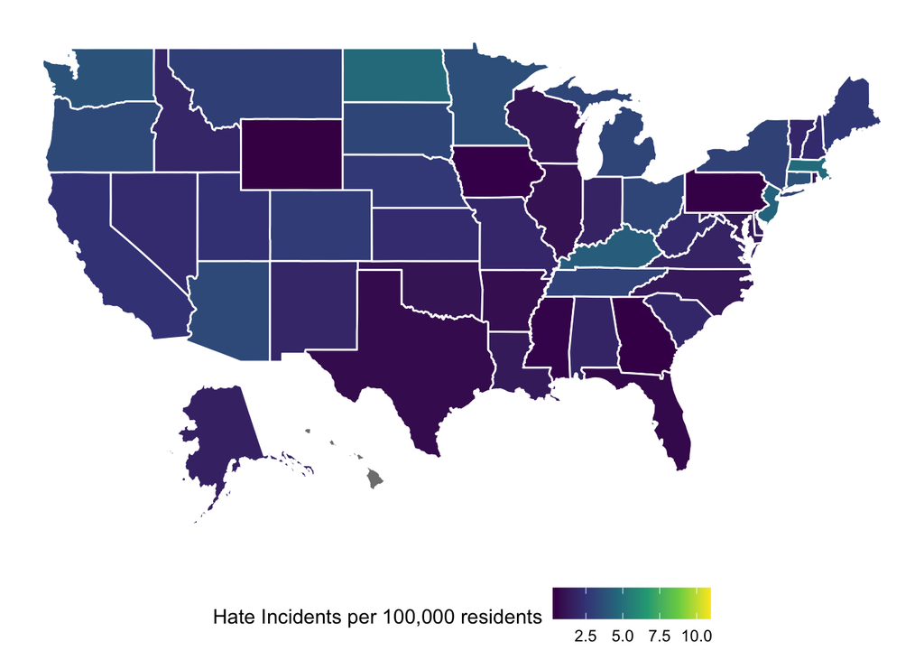

```r
#Before
ggplot(us) +
  geom_sf(aes(fill = crime_rate), color = "white", data = crime_map_before) +
  scale_fill_viridis_c(name = "Hate Incidents per 100,000 residents", option = "D") +
  theme_void() +
  theme(legend.position = "bottom")
```

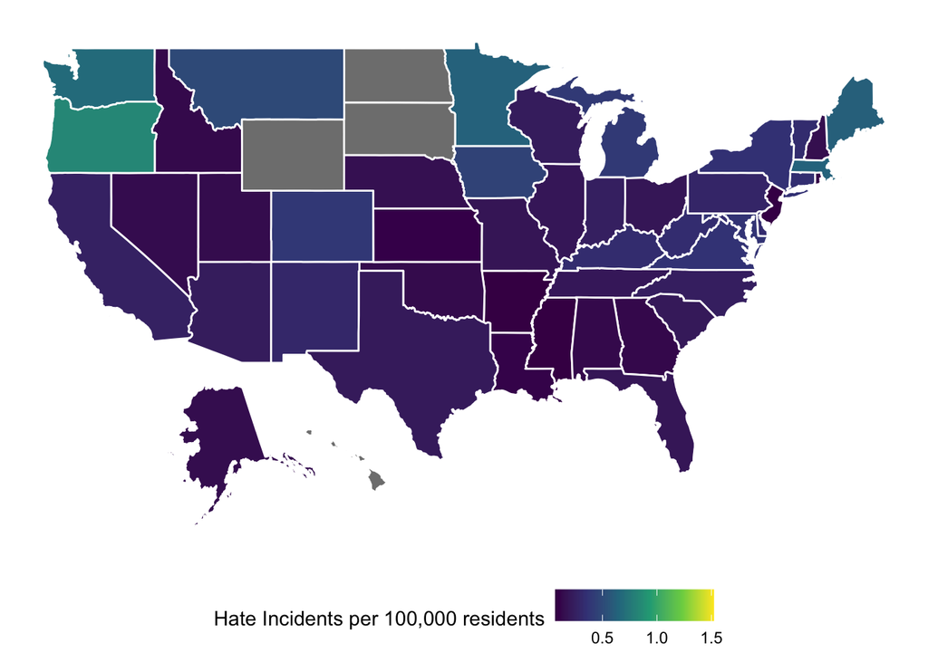

```r
#After
ggplot(us) +
  geom_sf(aes(fill = crime_rate), color = "white", data = crime_map_after) +
  scale_fill_viridis_c(name = "Hate Incidents per 100,000 residents", option = "D") +
  theme_void() +
  theme(legend.position = "bottom")
```